# Data_Analytics_Project

2022-11-15

Students: Marina Camí, Oscar Paz, Lidia Álvarez, Joel Rodríguez, Josep Franqueza

# 1 - Getting to know the datasets

```r
# Load datasets
PR <- read.csv("cookie_cats_purch.csv")
nrow(PR)
```

```
## [1] 4563
```

```r
ncol(PR)
```

```
## [1] 2
```

```r
summary(PR)
```

```
##        id             purch
##  Min.   :  26083   Length:4563
##  1st Qu.:2315481   Class :character
##  Median :4604331   Mode  :character
##  Mean   :4863477
##  3rd Qu.:7489164
##  Max.   :9999710
##  NA's   :3
```

# 2 - Preprocessing

## 2.1 - Preprocessing dataset “Cookie Cats AB Testing”

```r
unique(DS$version)
```

```
## [1] "gate_30" "gate_40"
```

```r
unique(DS$sum_gamerounds)
```

```
##   [1]     3    38   165     1   179   187     0     2   108   153    30    39
##  [13]   305    73    14   204     9     5    45   105     4    80    53    37
##  [25]    13    50   202    23   103    27    15    49     7   386    25    12
##  [37]     6    29   136    10    76   138    94    26   127    21   297    33
##  [49]   139    19    16    95     8   106    22    11   246    54    66   122
##  [61]    75    17    24    47    31    34    56    60    67    42    65   129
##  [73]    51    46   104    36    20    74    72    18    79    99    91   149
##  [85]    68   277   493   274    32    85   191   115   134   152   100   250
##  [97]   147   391    61    57    35    77   197    69   260    48   270    59
## [109]   141   467    40    43    93   222   334    58    84    41   303   177
## [121]   216   227    87    71   567    55    78   552    96   107    28   113
## [133]   339   452   148   163   220    63   290    86   356   117   298   338
## [145]   170   174    70   543   399   237   902   125   269   510    62    52
## [157]   474    83   121   210  1906   199   118   259    98   128   215   231
## [169]   160   110   275    44   133    88   282   132   183   112   332   798
```

[output cut: 64 more lines]

```r
unique(DS$retention_1) #Doing this we can search inconsistencies, like there are FALSE " false" and TRUE " true " variables when it should only be FALSE and TRUE
```

```
## [1] "FALSE"   "TRUE"    "false "  "  true "
```

```r
DS$retention_1[DS$retention_1 == "false "] = FALSE #Changing that "false " into FALSE so we have only one FALSE value
DS$retention_1[DS$retention_1 == "  true "] = TRUE #Changing that " true " into TRUE so we have only one TRUE value

unique(DS$retention_1) #to check if we change the values correctly.
```

```
## [1] "FALSE" "TRUE"
```

```r
DS$retention_1 = as.logical(DS$retention_1) #now our values in retention_1 are logical values. Before doing that they where strings.
unique(DS$retention_1) #to check if we change the values correctly again.
```

```
## [1] FALSE  TRUE
```

```r
unique(DS$retention_7)
```

```
## [1] FALSE  TRUE
```

```r
DS <- DS[-which.max(DS$sum_gamerounds),] #We remove the max sum_gamerounds that is very very high
```

We’ve changed some inconsistencies from DS, like some true and false values that were wrongly introduced. There were TRUE, FALSE, ” false” and ” true ” values. We’ve changed all into only boolean values (TRUE and FALSE).

## 2.2 - Preprocessing dataset “Cookie Cats Purchases”

```r
#Check the data set for inconsistencies on the values
unique(PR$id)
```

```
##   [1] 5696479 6682624 1698475 4520146 5081239 1177780 4334785  331668   45698
##  [10] 6170568 6534794 6570905 7427454 1573361 1250389 8879130 3185587 3342019
##  [19] 4869565 9690596 7740125 2153506 2749949  401693 4089079  711350 2057414
##  [28] 6066273 8555727  679368  231622 9534732  829861 5289541 9491204 8528948
##  [37] 7473331 5367116 6117101 9900264 3559799 1141788 4691712 2123028 8502069
##  [46] 8524603 4993000 9793515 5583035 1056410 9784981 7341723 5611185 3080597
##  [55] 9816646 6526449 2817782  864953 1844827 5316594 8448045 4914259 3657460
##  [64] 3239701 6230120   52100 2315481  563157 3891333 1519717 7430333 9383956
##  [73] 5962930  550581 4390164  495051 6393484 9272438 5687635 8686506  722652
##  [82] 5393303   26083 9981465 7390906 8288691 4625054 3837980 4251670 7810642
##  [91] 1644294 2911012 1587019 2098970 6438242 4368721 4200856 6773715 3235704
## [100] 7699053 9418344 2577655 2778534 1744280 1381459 3593062 8007106 4927174
## [109] 1363026 4124082 7663436 4561130 6667511 9999710 6082972 2563451 8429621
## [118] 1763807 8198556 9979214 1904622 3536465 5430868 2752038 4639409 9577522
## [127] 1045169 1139929 7069181 8804668 7397157 3237174 5226626 4643567  104999
```

[output cut: 96 more lines]

```r
unique(PR$purch)
```

```
##  [1] "10.99EUR"  "2.29EUR"   "54.99EUR"  NA          "21.99EUR"  "109.99EUR"
##  [7] "-2.29EUR"  "-54.99EUR" "-10.99EUR" "-21.99EUR"
```

```r
#Change all negatives values to positives values
PR$purch <- gsub("-", "", PR$purch)

#Remove all NA values in the dataset
PR <- na.omit(PR)

#Check again to be sure there are no more inconsistencies
unique(PR$id)
```

```
##   [1] 5696479 6682624 1698475 4520146 5081239 1177780 4334785  331668   45698
##  [10] 6170568 6534794 6570905 7427454 1573361 1250389 8879130 3185587 3342019
##  [19] 4869565 7740125 2153506 2749949  401693 4089079  711350 2057414 6066273
##  [28] 8555727  679368  231622 9534732  829861 5289541 9491204 8528948 7473331
##  [37] 5367116 9900264 3559799 1141788 4691712 2123028 8502069 8524603 4993000
##  [46] 9793515 5583035 1056410 9784981 7341723 5611185 3080597 9816646 6526449
##  [55] 2817782  864953 1844827 5316594 8448045 4914259 3657460 3239701 6230120
##  [64]   52100 2315481  563157 3891333 1519717 7430333 9383956 5962930  550581
##  [73] 4390164  495051 6393484 9272438 5687635 8686506  722652 5393303   26083
##  [82] 9981465 7390906 8288691 4625054 3837980 4251670 7810642 1644294 2911012
##  [91] 1587019 2098970 6438242 4368721 4200856 6773715 3235704 7699053 9418344
## [100] 2577655 2778534 1744280 1381459 3593062 8007106 4927174 1363026 4124082
## [109] 7663436 4561130 6667511 9999710 6082972 2563451 8429621 1763807 8198556
## [118] 9979214 1904622 3536465 5430868 2752038 4639409 9577522 1045169 1139929
## [127] 7069181 8804668 7397157 3237174 5226626 4643567  104999 1433068 6313965
```

[output cut: 96 more lines]

```r
unique(PR$purch)
```

```
## [1] "10.99EUR"  "2.29EUR"   "54.99EUR"  "21.99EUR"  "109.99EUR"
```

We’ve changed negative values into positive ones by erasing - sign in some values from PR. We’ve also removed all NA values from PR.

# 3 - Descriptive analytics

## 3.1 - Dataset “Cookie Cats AB Testing”

### 3.1.1 - Users that downloaded the game

```r
totalUserAmmount <- length(DS$userid)
totalUserAmmount
```

```
## [1] 90188
```

Here we observed length related to userid value to know how many users downloaded the game. There are actually 90.188 users.

### 3.1.2 - Distribution of users in groups

```r
#Check the amount of users for each group of the A/B test
g30_UserAmmount <- length(DS$userid[DS$version == "gate_30"])
g40_UserAmmount <- length(DS$userid[DS$version == "gate_40"])

#Verify that the sum of the amount of users per group is equal to the totalilty of users
g30_UserAmmount + g40_UserAmmount == totalUserAmmount
```

```
## [1] TRUE
```

```r
g30_Percentile <- (g30_UserAmmount / totalUserAmmount) * 100
g30_Percentile
```

```
## [1] 49.56203
```

```r
g40_Percentile <- (g40_UserAmmount / totalUserAmmount) * 100
g40_Percentile
```

```
## [1] 50.43797
```

```r
#There's a slightly higher amount of users in gate40 than in gate30, precisely a 0.88% more
(g40_Percentile - g30_Percentile)
```

```
## [1] 0.875948
```

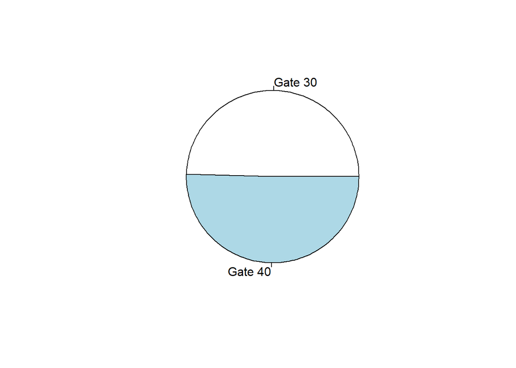

```r
#We draw a pie chart to see that difference more clearly
pie(c(g30_UserAmmount, g40_UserAmmount),  c("Gate 30", "Gate 40"))
```

We’ve divided the total amount of player into two groups, gate30 and gate40. To do that we’ve searched all players with version gate_30. We’ve done the same with players with version gate_40.

Gate 30 users: 44.699 users Gate 40 users: 45.489 users

To know the percentage we’ve divided the amount of gate30 users into the totalUserAmount to know exactly how many players with version gate30 were. We’ve done the same with gate40 users.

### 3.1.3 - Game rounds

What is the distribution of game rounds in the players’ population? We’ve used a boxplot to visually represent the distribution of game rounds.

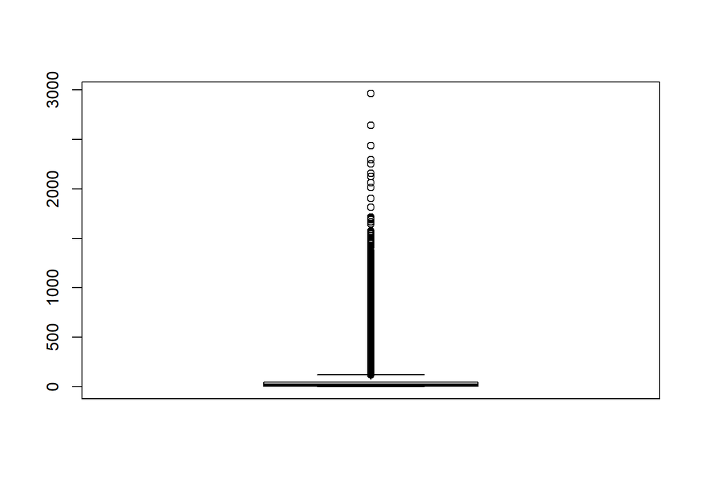

```r
boxplot(DS$sum_gamerounds)
```

And among the users of version A and version B of the game separately?

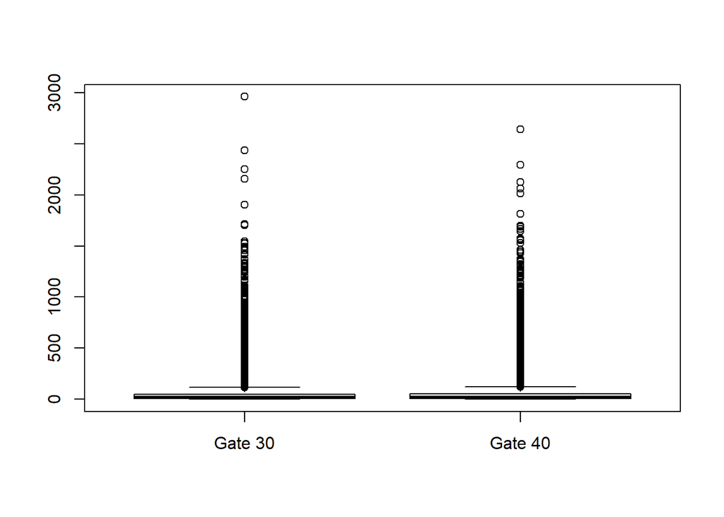

```r
boxplot(DS$sum_gamerounds[DS$version == "gate_30"], DS$sum_gamerounds[DS$version == "gate_40"], names = c("Gate 30", "Gate 40"))
```

```r
totalGamerounds = sum(DS$sum_gamerounds)
gate30Gamerounds = sum(DS$sum_gamerounds[DS$version == "gate_30"])
gate40Gamerounds = sum(DS$sum_gamerounds[DS$version == "gate_40"])
```

We’ve used a boxplot to visually represent the distribution of game rounds by dividing this into gate30 group and gate40 group.

### 3.1.4 - Retention

What is the value of retention at day 1? (percentage of users that are still active the day after installation).

```r
# ---------- RETENTION 1 ----------
#Percentage of users with version gate_30 that are still active the day after installation (among all players with gate_30)
g30Ret1 = length(DS$version[DS$version == "gate_30" & DS$retention_1 == TRUE])
g30Ret1Percentage = (g30Ret1/ g30_UserAmmount) * 100
g30Ret1Percentage
```

```
## [1] 44.81979
```

```r
#Percentage of users with version gate_40 that are still active the day after installation (among all players with gate_40)
g40Ret1 = length(DS$version[DS$version == "gate_40" & DS$retention_1 == TRUE])
g40Ret1Percentage = (g40Ret1/ g40_UserAmmount) * 100
g40Ret1Percentage
```

```
## [1] 44.22827
```

```r
#There's a slighlty higher retention_1 of users in gate_30 than in gate_40
(g30Ret1Percentage - g40Ret1Percentage)
```

```
## [1] 0.5915197
```

To calculate retention percentage we’ve done: 1. Calculate all players in gate30 group and gate40 group that have been retained and are still active he day after installation. 2. Divide this amount the players among all players in gate30 and multiplied by 100 to know the percentage of Retention1 of gate30 players.

Retention 1 gate30 percentage: 44,82% Retention 1 gate40 percentage: 44,23%

We’ve done the same for gate40 group.

What is the value of retention at day 7? (percentage of users that are still active after one week of installation).

```r
# ---------- RETENTION 7 ----------
#Percentage of users with version gate_30 that are still active after one week of installation (among all players with gate_30)
g30Ret7 = length(DS$version[DS$version == "gate_30" & DS$retention_7 == TRUE])
g30Ret7Percentage = (g30Ret7/ g30_UserAmmount) * 100
g30Ret7Percentage
```

```
## [1] 19.01832
```

```r
#Percentage of users with version gate_40 that are still active after one week of installation (among all players with gate_40)
g40Ret7 = length(DS$version[DS$version == "gate_40" & DS$retention_7 == TRUE])
g40Ret7Percentage = (g40Ret7/ g40_UserAmmount) * 100
g40Ret7Percentage
```

```
## [1] 18.2
```

```r
#There's a slighlty higher retention_1 of users in gate_30 than in gate_40
(g30Ret7Percentage - g40Ret7Percentage)
```

```
## [1] 0.8183182
```

We’ve done the same for retention 7 like we did with retention 1. Retention 7 gate30 percentage: 19,02% Retention 7 gate40 percentage: 18,2%

### 3.1.5 - Are there non-playing users?

```r
#To know if there are nonplayers, we have to look sum_gamerounds. If they've played  0 rounds, it means they didn't play the game.
#Searching for non players (sum_gamerounds = 0)
nonPlayersAmmount = length(DS$sum_gamerounds[DS$sum_gamerounds == 0])
nonPlayersAmmount
```

```
## [1] 3994
```

```r
#NonPlayers in percentage
nonPlayersPercentage = (nonPlayersAmmount / totalUserAmmount) * 100
nonPlayersPercentage
```

```
## [1] 4.428527
```

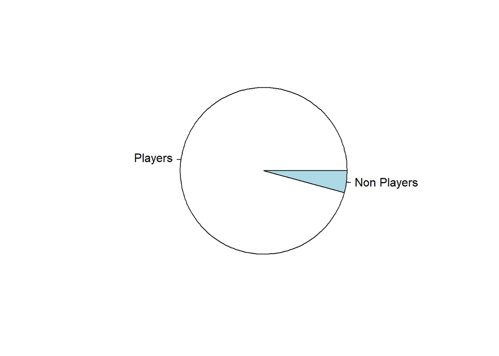

```r
#Piechart
names = c("Players", "Non Players")
variables = c(totalUserAmmount, nonPlayersAmmount)

pie(variables, names)
```

We’ve searched how many players have 0 game rounds, so we can know they are non players. We know that there are 3.994 users with no game rounds.

## 3.2 - Dataset “Cookie Cats Purchases”

We are going to create a piechart that represents in which range of payment we have more users, we have divided it into three ranges. The players that have spent between 0-30€, the ones that have spent between 30-60€ and the ones that have spent more than 60€.

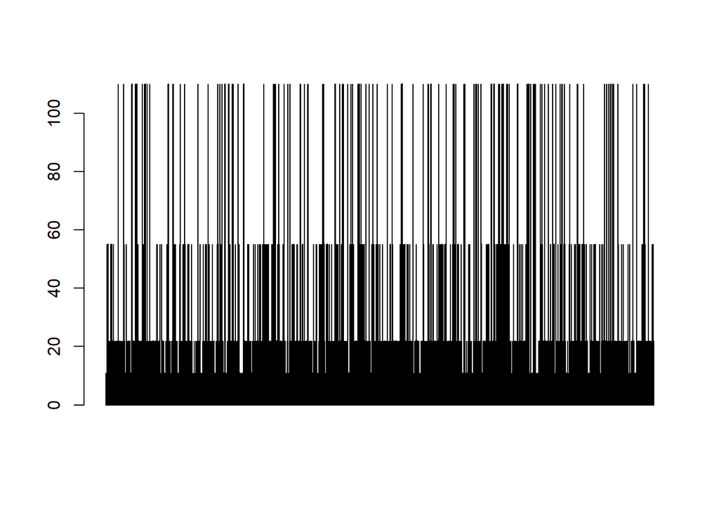

```r
#Fixing purch to sum up all the purchases. To do that, we split our string purch to use only the numbers and get rid of EUR.
purchFixed = strsplit(PR$purch, split = "EUR")
newPurchFixed = as.vector(unlist(purchFixed))
newPurchFixed = as.numeric(newPurchFixed)

barplot(newPurchFixed)
```

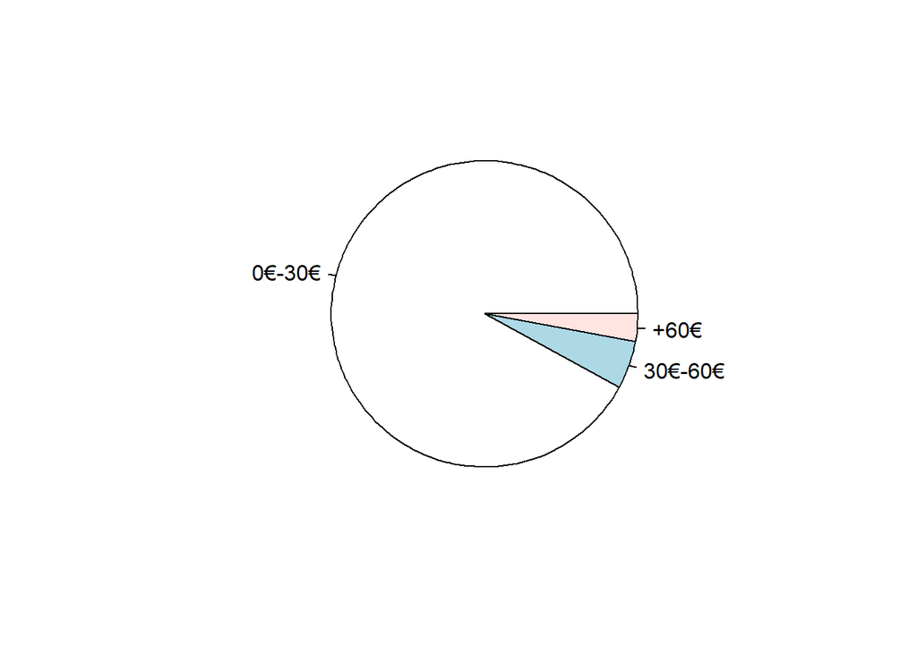

```r
minPurchaseGroup <- newPurchFixed[newPurchFixed <= 30] #the have spent between 0€ and 30€
medPurchaseGroup <- newPurchFixed[newPurchFixed < 60 & newPurchFixed > 30]#they have spent between 30€ and 60€
maxPurchaseGroup <- newPurchFixed[newPurchFixed >= 60]#They have spent more than 60€

var = c(length(minPurchaseGroup), length(medPurchaseGroup), length(maxPurchaseGroup))
levels = c("0€-30€", "30€-60€", "+60€")

pie(var, levels)
```

From the data we can see that the majority of the players spend between 0€ and 30€.

# 4 - Monetization metrics

To know the ARPU: 1. We’ve sum all purchases to know how much did players pay. 2. We’ve divided the sum by the amount of total users.

To know the ARRPU: We’ve divided all purchases by the number of PAYING users.

```r
#ARPU - Average Revenue Per User

allPurch = sum(newPurchFixed)

#Now we compute our ARPU
arpu = allPurch / totalUserAmmount
arpu
```

```
## [1] 0.7082533
```

```r
#ARRPU - Average Revenue Per Paying User
#computing the number of players who pay
payingUsers = length(unique(PR$id))
arrpu = allPurch / payingUsers
arrpu
```

```
## [1] 64.45605
```

```r
#Conversion Rate
conversionRate = payingUsers/totalUserAmmount
conversionRate
```

```
## [1] 0.01098816
```

```r
conversionRate * 100
```

```
## [1] 1.098816
```

# 5 - A/B Testing

Research question: Does moving gate to level 40 improve engagement of the users significantly?

## 5.1 - Hypothesis

We’ll consider the number of round games of every user. Sample A = round games gate 30 Sample B = round games gate 40

Null Hypothesis: Sample B <= Sample A

Alternative Hypothesis: Sample B > Sample A

## 5.2 - Visualisation

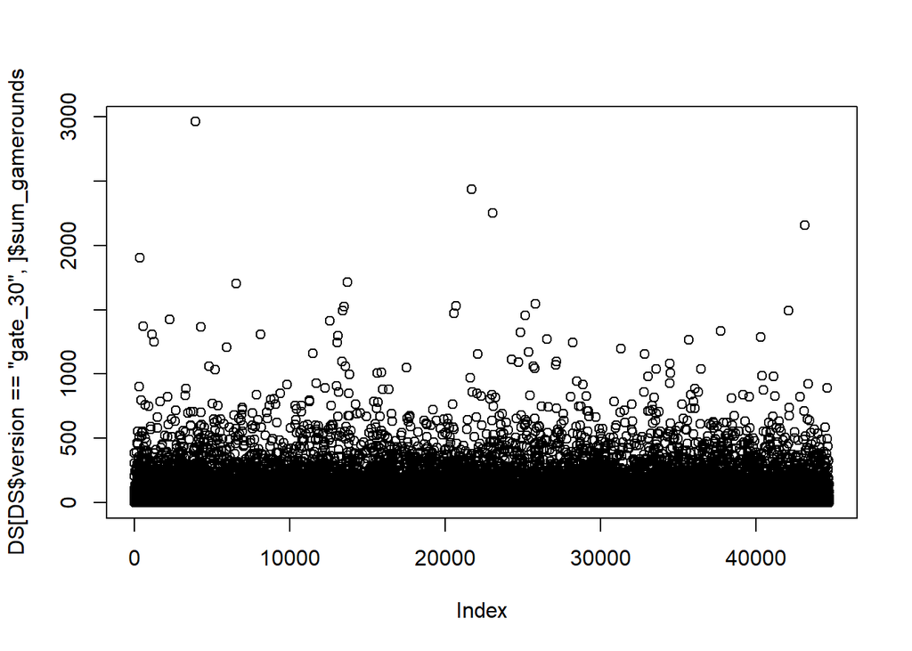

```r
plot(DS[DS$version == "gate_30",]$sum_gamerounds)
```

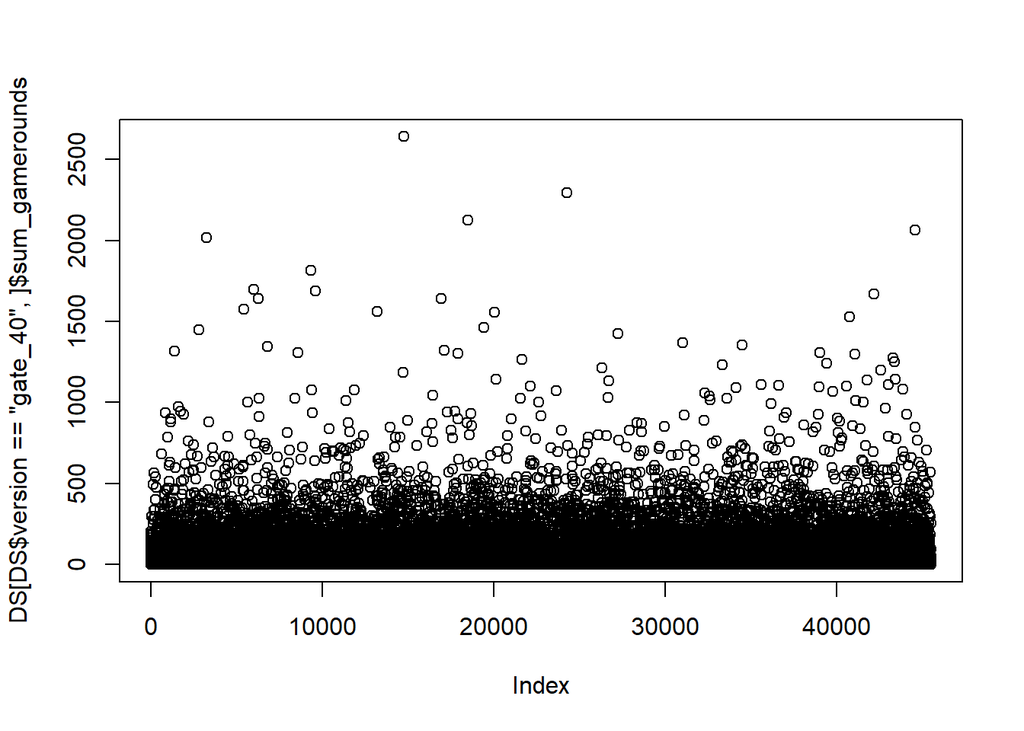

```r
plot(DS[DS$version == "gate_40",]$sum_gamerounds)
```

## 5.3 - Computation

We’ve calculated:

```r
#Confidence level = 95%

#Significance level = 0.05
```

1. The mean of game rounds of gate30 group and gate40 group.

```r
#mean
meanGameroundsGate30 = mean(DS$sum_gamerounds[DS$version == "gate_30"])
meanGameroundsGate30
```

```
## [1] 51.34211
```

```r
meanGameroundsGate40 = mean(DS$sum_gamerounds[DS$version == "gate_40"])
meanGameroundsGate40
```

```
## [1] 51.29878
```

2. The standard deviaton of the sum of game rounds of gate30 and gate40 group.

```r
#sd
sdGate30 = sd(DS$sum_gamerounds[DS$version == "gate_30"])
sdGate30
```

```
## [1] 102.0576
```

```r
sdGate40 = sd(DS$sum_gamerounds[DS$version == "gate_40"])
sdGate40
```

```
## [1] 103.2944
```

3. The number of samples in each group.

```r
#number of samples
n1 = length(DS$sum_gamerounds[DS$version == "gate_30"])
n1
```

```
## [1] 44699
```

```r
n2 = length(DS$sum_gamerounds[DS$version == "gate_40"])
n2
```

```
## [1] 45489
```

4. The observed Statistic.

```r
#Observed statistic
diffmeans = (meanGameroundsGate40 - meanGameroundsGate30)
squareRoot = sqrt((sdGate30)^2/n1 + (sdGate40)^2/n2)
obsStat =  diffmeans/squareRoot
obsStat
```

```
## [1] -0.06337426
```

5. The degree of freedom.

```r
#degree of freedom (df)
p1 = ((sdGate30)^2/n1 + (sdGate40)^2/n2)^2
p2.1 = (((sdGate30)^2/n1)^2) / (n1 - 1)
p2.2 = (((sdGate40)^2/n2)^2) / (n2 - 1)

df = p1 / (p2.1 + p2.2)
df
```

```
## [1] 90183.3
```

6. pvalue and critical value to know if we can accept the hypothesis or not.

```r
#pvalue
pvalue = pt(obsStat, df, lower.tail = FALSE)
pvalue
```

```
## [1] 0.5252657
```

```r
#critical value (z)
z = qt(0.05, df, lower.tail = FALSE)
z
```

```
## [1] 1.644871
```

## 5.4 - Conclusion of A/B testing

We can not accept the alternative hypothesis because the observed value (tobs) is smaller than the critical value (z) needed for the acceptance of the alternative hypothesis.

```r
obsStat > z
```

```
## [1] FALSE
```

This is caused because the difference between the game round mean between gate30 and gate40 is very little so we cannot know if moving from one gate to another will engage people. We will need more samples to prove it.

# 6 - Regresion analysis

## 6.1 - Visual representation

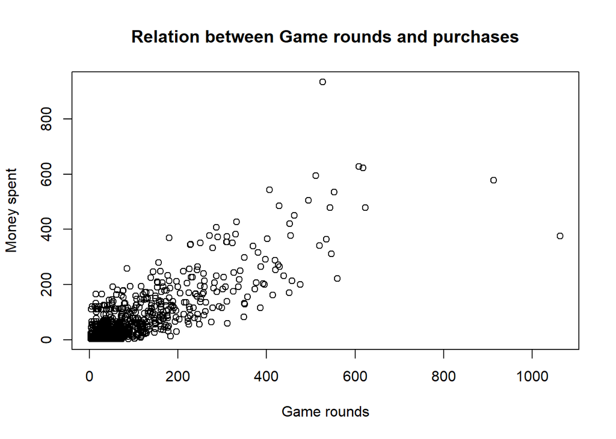

```r
PR_OnlyNums = data.frame(PR$id, as.numeric(gsub("[A-Za-z]" , "", PR$purch)))
colnames(PR_OnlyNums) = c("id", "purch")
PR_sumPurch <- aggregate(purch ~ id, PR_OnlyNums, sum)
PurchasexRound = merge(DS, PR_sumPurch, by.x="userid", by.y="id")
plot(PurchasexRound$sum_gamerounds, PurchasexRound$purch, main = "Relation between Game rounds and purchases", xlab = "Game rounds", ylab = "Money spent")
```

## 6.2 - Building the model

```r
mylm = lm(purch ~ sum_gamerounds, PurchasexRound)
mylm
```

```
##
## Call:
## lm(formula = purch ~ sum_gamerounds, data = PurchasexRound)
##
## Coefficients:
##    (Intercept)  sum_gamerounds
##         3.6990          0.6983
```

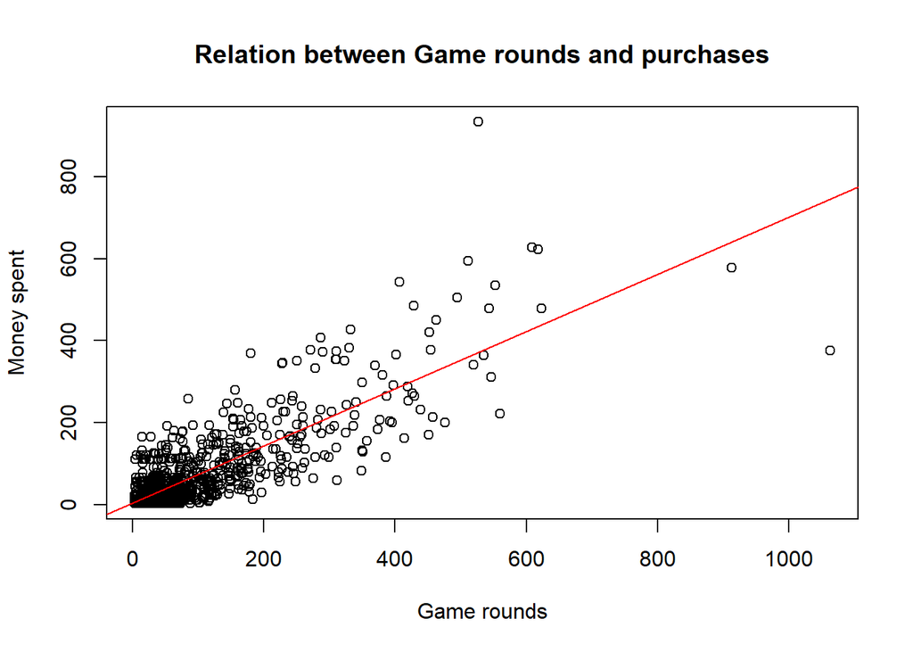

```r
plot(PurchasexRound$sum_gamerounds, PurchasexRound$purch, main = "Relation between Game rounds and purchases", xlab = "Game rounds", ylab = "Money spent")
abline(mylm, col = "Red")
```

The regresion line simbolizes the mean change of the dependent variable as the independent variable progresses based on a 0.6983 coeficient per unit.

## 6.3 - Model fit

```r
summary(mylm)
```

```
##
## Call:
## lm(formula = purch ~ sum_gamerounds, data = PurchasexRound)
##
## Residuals:
##     Min      1Q  Median      3Q     Max
## -370.37  -22.02   -7.38    9.67  562.16
##
## Coefficients:
##                Estimate Std. Error t value Pr(>|t|)
## (Intercept)     3.69905    2.19843   1.683   0.0928 .
## sum_gamerounds  0.69828    0.01549  45.090   <2e-16 ***
## ---
## Signif. codes:  0 '***' 0.001 '**' 0.01 '*' 0.05 '.' 0.1 ' ' 1
##
## Residual standard error: 54.68 on 989 degrees of freedom
## Multiple R-squared:  0.6727, Adjusted R-squared:  0.6724
## F-statistic:  2033 on 1 and 989 DF,  p-value: < 2.2e-16
```

## 6.4 - Predict a case

```r
invest <- 50
new.ds <- data.frame( sum_gamerounds=invest )
predict(mylm, new.ds)
```

```
##        1
## 38.61282
```